# Pronosticos_30_Mayo_Ibarra_Sergio_Concentracion

Sergibar

2023-05-30

## UNAM Maestría en Ingeniería de Sistemas

## Dr. Jair Morales Camarena

## Alumno: Ibarra Ramírez Sergio

Importación de librerias necesarias para trabajar

```r
library(tidyverse)      # data manipulation and visualization
library(lubridate)      # easily work with dates and times
library(fpp2)           # working with time series data
library(zoo)
```

```r
library(ggplot2)
library(plyr)
library(dplyr)
library(knitr)
library(TTR)
library(hydroGOF)
```

# Concentracion Carbono

### Importación de los datos de nuestra serie que se va a llamar datos_original

```r
library(readxl)
# Read the Excel file
concentracion_datos_original <- read_excel('concentracionCO.xlsx')

# View the imported data
print(concentracion_datos_original)
```

```
## # A tibble: 153 × 2
##      AÑO CONCEN
##    <dbl>  <dbl>
##  1  1975   331.
##  2  1975   331.
##  3  1975   332.
##  4  1975   333.
##  5  1975   334.
##  6  1975   333.
##  7  1975   332.
##  8  1975   330.
##  9  1975   329.
## 10  1975   328.
## # … with 143 more rows
```

Nos aseguramos que la data se haya importado correctamente

```r
summary(concentracion_datos_original)
```

```
##       AÑO           CONCEN
##  Min.   :1975   Min.   :328.4
##  1st Qu.:1978   1st Qu.:334.8
##  Median :1981   Median :339.9
##  Mean   :1981   Mean   :339.6
##  3rd Qu.:1984   3rd Qu.:344.2
##  Max.   :1987   Max.   :351.7
```

```r
typeof(concentracion_datos_original)
```

```
## [1] "list"
```

```r
dim(concentracion_datos_original)
```

```
## [1] 153   2
```

#### Convertimos los concentracion_datos_original a Serie de tiempo

Al observar la data se determina que existe una especie de estacionalidad que se repite cada 12 meses

```r
concentracion_datos_original_ts<- ts(concentracion_datos_original$CONCEN, frequency = 12)
head(concentracion_datos_original_ts)
```

```
##      Jan    Feb    Mar    Apr    May    Jun
## 1 330.62 331.40 331.87 333.18 333.92 333.43
```

```r
typeof(concentracion_datos_original_ts)
```

```
## [1] "double"
```

Graficamos la serie del tiempo

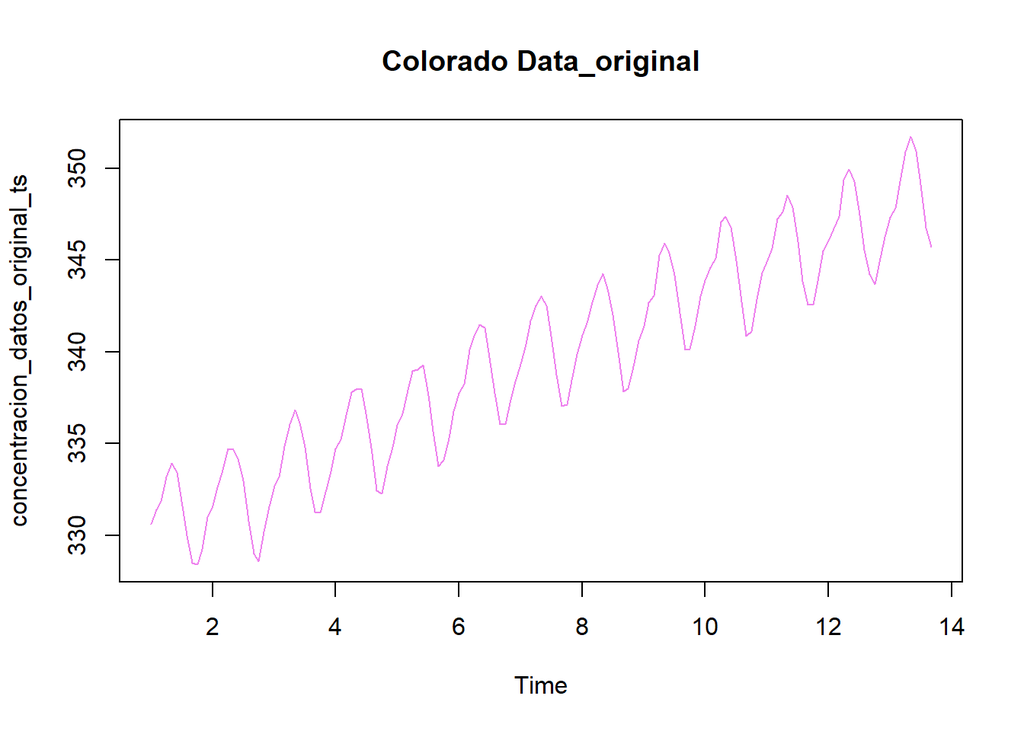

```r
plot(concentracion_datos_original_ts, col = "violet", main = "Colorado Data_original")
```

### Vamos a descomponer la data usando el metodo decompose para entender sus compoentes de tren, seasonalidad y aleatorio

```r
concentracion_datos_original_ts_decompose <- decompose(concentracion_datos_original_ts)
summary(concentracion_datos_original_ts_decompose)
```

```
##          Length Class  Mode
## x        153    ts     numeric
## seasonal 153    ts     numeric
## trend    153    ts     numeric
## random   153    ts     numeric
## figure    12    -none- numeric
## type       1    -none- character
```

Vamos a plotear la desmposición

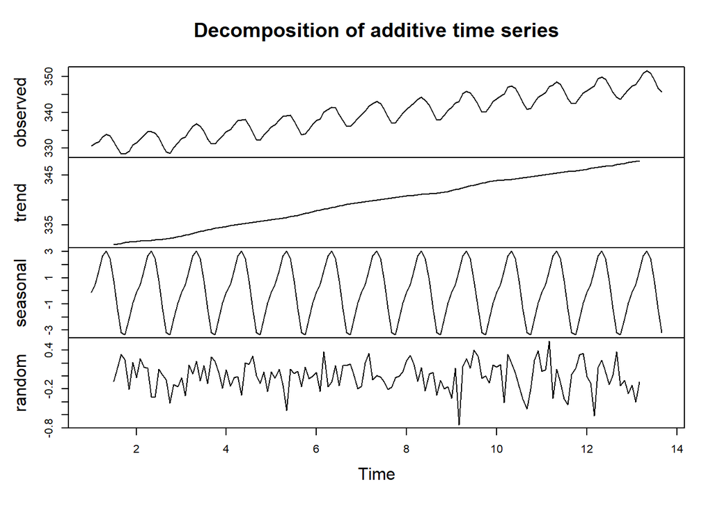

```r
plot(concentracion_datos_original_ts_decompose)
```

En general para los componentes de trend, estacionalidad y randomnes de nuestra variable Y se observa:

- Trend: Una clara tendencia en aumento
- Estacionalidad: Se observa un componente repetitivo ciclico cada 12 meses
- Random: Se observa una especie de ruido blanco, con media cero y una sd de alrededor de 0.4